# MCMC Diagnostics

```r
library(mcmcplots)
library(coda)
print(getwd())
```

```
[1] "/Users/zhoulinn/Projects/gait_jags/src"
```

```r
# import r2jags data
n <- 3
analyses <- list(
  "jags_output",  # the standard model
  "jags_output_left_foot_downsample_2",  # with downsampled stride-by-stride data
  "cauchy_conjugate_jags_output_left_foot_downsample_5"
  )
data.r2jags <- get(load(file.path("..", "data", "processed", analyses[[n]], "data_r2jags_AR1_stride_lengths_sub_01.RData")))   #
```

```r
# explore interactions by applying specific contrasts to the already fit model
mcmc <- data.r2jags$BUGSoutput$sims.matrix
wch = grep("^beta", colnames(mcmc))
newdata = expand.grid(A = levels(data$fatigue), B = levels(data$condition))
```

```
Error in data$fatigue : object of type 'closure' is not subsettable
```

Print posterior estimates

```r
print(data.r2jags$BUGSoutput$summary)
```

[output not shown]

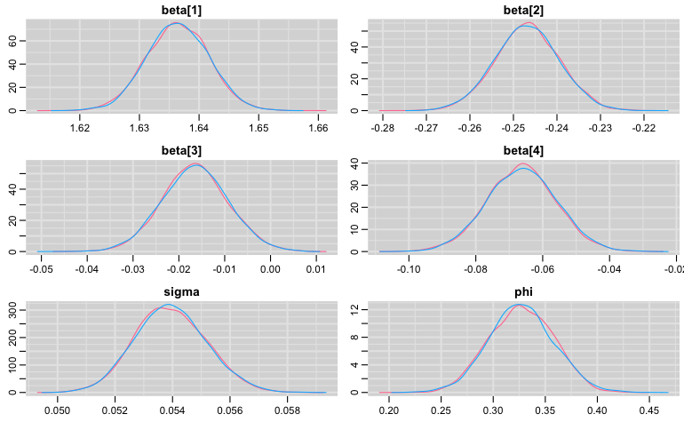

```r
# density plot
denplot(data.r2jags, parms = c("beta", "sigma", "phi"))
```

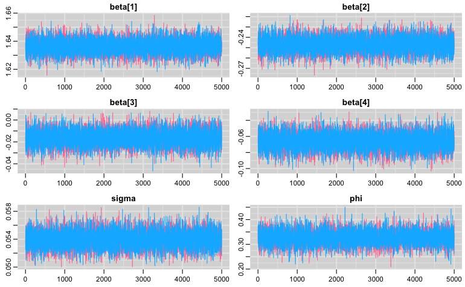

```r
# trace plot
traplot(data.r2jags, parms = c("beta", "sigma", "phi"))
```

Running plots Running plots show each posterior draw per iteration by variable for each chain. The dark line in this plot indicates the posterior mean for that chain. We want these means to be as equal as possible, or make sure that the chains are exploring the same area. For both chains, we also want to see the draws from the posterior distribution stay as close as possible to the posterior mean. If the observations bounce around too much, it is an indication that the posterior has not reached a stationary distribution. https://static1.squarespace.com/static/610c1467ea1d4a02e9c1a010/t/610c3e967c967e2ab20086d6/1628192407632/BayesLabDay3.pdf

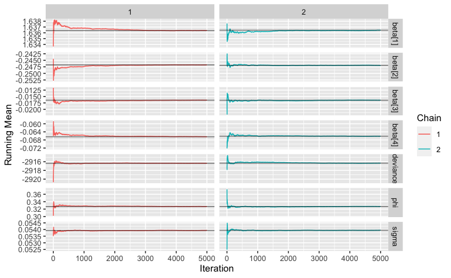

```r
library(ggmcmc)
data.gg<-ggs(as.mcmc(data.r2jags))
ggs_running(data.gg)
```

```r
# ggs_traceplot(data.gg)
```

Raftery diagnostics: require no more than N samples to reach the specified level of confidence in convergence You can interpret this test by looking at the feasibility of convergence. Generally speaking, you want for the total number of needed iterations to be less than 100,000. Any more than 100,000 gives cause for concern. https://rdrr.io/cran/coda/man/raftery.diag.html

```r
data.mcmc = as.mcmc(data.r2jags)

# raftery diagnostics
raftery.diag(data.mcmc)
```

```
[[1]]

Quantile (q) = 0.025
Accuracy (r) = +/- 0.005
Probability (s) = 0.95

          Burn-in  Total Lower bound  Dependence
          (M)      (N)   (Nmin)       factor (I)
 beta[1]  2        3866  3746         1.030
 beta[2]  2        3930  3746         1.050
 beta[3]  2        3680  3746         0.982
 beta[4]  2        3866  3746         1.030
 deviance 2        3803  3746         1.020
 phi      5        5771  3746         1.540
 sigma    3        4198  3746         1.120


[[2]]

Quantile (q) = 0.025
Accuracy (r) = +/- 0.005
Probability (s) = 0.95

          Burn-in  Total Lower bound  Dependence
          (M)      (N)   (Nmin)       factor (I)
 beta[1]  2        3680  3746         0.982
 beta[2]  2        3680  3746         0.982
 beta[3]  2        3741  3746         0.999
 beta[4]  2        3620  3746         0.966
 deviance 2        3803  3746         1.020
 phi      6        7131  3746         1.900
 sigma    3        4062  3746         1.080
```

Geweke Test The Geweke Test compares the posterior mean of the first half of a Markov chain to the second half. Under this test, the null hypothesis that the model has achieved convergence. Therefore, we do not want to reject the null hypothesis. The following code demonstrates how to conduct the Geweke test on your Bayesian model. The Geweke test also comes with a plot version of the results. https://static1.squarespace.com/static/610c1467ea1d4a02e9c1a010/t/610c3e967c967e2ab20086d6/1628192407632/BayesLabDay3.pdf

```r
geweke.diag(data.mcmc)
```

```
[[1]]

Fraction in 1st window = 0.1
Fraction in 2nd window = 0.5

 beta[1]  beta[2]  beta[3]  beta[4] deviance      phi    sigma
  2.5248  -2.8624  -1.4992   2.3606  -0.4882   1.1263  -0.4242


[[2]]

Fraction in 1st window = 0.1
Fraction in 2nd window = 0.5

 beta[1]  beta[2]  beta[3]  beta[4] deviance      phi    sigma
 -1.6068   0.4841  -1.1362   1.1172   1.2640  -0.5501  -0.4041
```

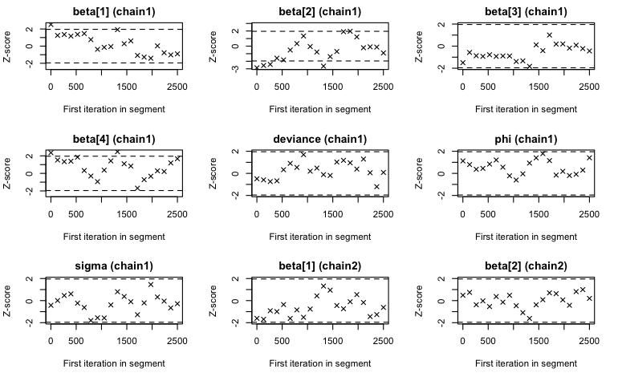

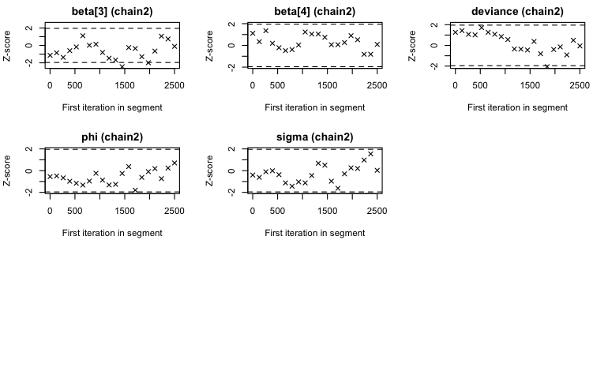

```r
geweke.plot(data.mcmc)
```

Autocorrelation for each parameter illustrate the degree of correlation between MCMC samples separated by different lags. For example, a lag of 0 represents the degree of correlation between each MCMC sample and itself (obviously this will be a correlation of 1). A lag of 1 represents the degree of correlation between each MCMC sample and the next sample along the chain and so on. In order to be able to generate unbiased estimates of parameters, the MCMC samples should be independent (uncorrelated).

```r
#Autocorrelation diagnostic
autocorr.diag(data.mcmc)
```

```
             beta[1]      beta[2]       beta[3]      beta[4]     deviance          phi       sigma
Lag 0   1.0000000000  1.000000000  1.0000000000  1.000000000  1.000000000  1.000000000 1.000000000
Lag 1  -0.0028248708  0.014469395 -0.0025654821  0.007631141  0.105196488  0.256665066 0.048446579
Lag 5   0.0099108727  0.004101308  0.0065590618  0.003072812  0.001091399  0.012909588 0.006854461
Lag 10 -0.0126231085 -0.013094325  0.0002415397 -0.007423554 -0.006566522  0.014101422 0.001757662
Lag 50 -0.0005368948 -0.009288520 -0.0078364992 -0.011559808  0.024128710 -0.001011078 0.001103416
```